# Homelessness

### Analysis

```r
# Set up model matrix
# Use combination of predictor variables and census region
x_train_region <- model.matrix(rate_homeless ~ utility_costs*census_region + share_renters_2016*census_region + share_overcrowded_units_2016*census_region + total_Jan_precipitation*census_region, train_region)[,-1]
y_train_region <- train_region$rate_homeless
```

```r
lasso_region_cv <- cv.glmnet(x_train_region, y_train_region, alpha = 1)
```

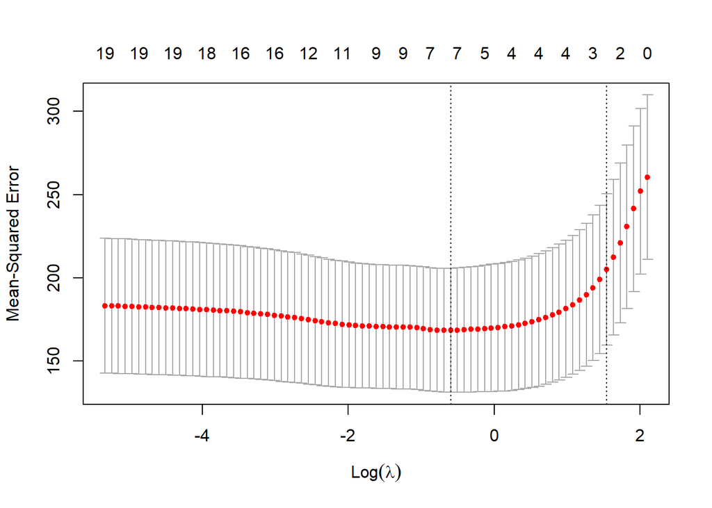

```r
plot(lasso_region_cv)
```

The minimum lambda has seven variables and the one standard error lambda has three variables.

```r
lasso_region_best_lam <- lasso_region_cv$lambda.1se
lasso_region_best_lam
```

```
## [1] 4.686155
```

The best lambda value (using one standard error) is 4.69.

```r
lasso_region_mod <- glmnet(x_train_region, y_train_region, alpha = 1, lambda = lasso_region_best_lam)

coef(lasso_region_mod)
```

```
## 20 x 1 sparse Matrix of class "dgCMatrix"
##                                                      s0
## (Intercept)                                 4.824719830
## utility_costs                               .
## census_region2                              .
## census_region3                              .
## census_region4                              .
## share_renters_2016                          0.294865292
## share_overcrowded_units_2016                .
## total_Jan_precipitation                     .
## utility_costs:census_region2                .
## utility_costs:census_region3                .
## utility_costs:census_region4                .
## census_region2:share_renters_2016           .
## census_region3:share_renters_2016           .
## census_region4:share_renters_2016           0.008331105
## census_region2:share_overcrowded_units_2016 .
## census_region3:share_overcrowded_units_2016 .
## census_region4:share_overcrowded_units_2016 .
## census_region2:total_Jan_precipitation      .
## census_region3:total_Jan_precipitation      .
## census_region4:total_Jan_precipitation      0.676110022
```

The variables with non-zero coefficients are share_renters_2016, the combination of share_renters_2016 and census_region4, and the combination of total_Jan_precipitation and census_region4.

```r
# Predict for test data
x_test_region <- model.matrix(rate_homeless ~ utility_costs*census_region + share_renters_2016*census_region + share_overcrowded_units_2016*census_region + total_Jan_precipitation*census_region, test_region)[,-1]
lasso_region_predict <- predict(lasso_region_mod, s = lasso_region_best_lam, newx = x_test_region)
```

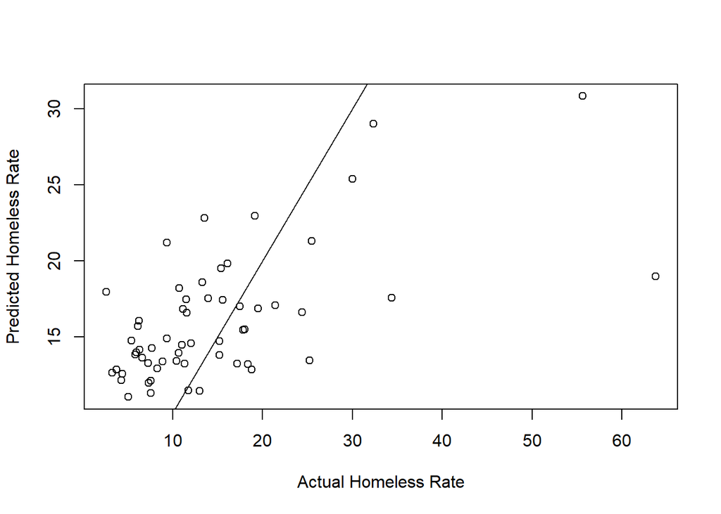

```r
plot(test_region$rate_homeless, lasso_region_predict, xlab = "Actual Homeless Rate", ylab = "Predicted Homeless Rate")
abline(0, 1)
```

The model is consistent with the initial lasso analysis. It overestimates homeless rates for lower rates, and underestimates it at higher rates.

```r
lasso_region_rmse <- (test_region$rate_homeless - lasso_region_predict)^2 %>%
  mean() %>%
  sqrt()
lasso_region_rmse
```

```
## [1] 9.352766
```

The RMSE is 9.35. It is similar to most of the RMSE values from the other models.

### Discussion

The only census region that had a non-zero coefficient in combination with another variable was census region 4, which is west. This region includes the entire west half of the continental US, Alaska, and Hawaii. Of the four variables, two of them (share_renters_2016 and total_Jan_precipitation) were significant with region 4. Total_Jan_precipitation did not have a coefficient on its own.

From these results, share_renters_2016 works as a predictor for homeless rates generally, and share_renters_2016 and total_Jan_precipitation can predict homeless rates in the western US.

## Conclusion

After completing your analyses, you will make your conclusions and communicate your results. Consult Canvas for further directions.

One limitation of the analysis has to do with the data. The data set has a small number of data points, but includes many variables for possible predictors. This makes it easier to possibly overfit the data, and fit the noise instead of the more general trend. Since we also split the data into training and testing sets, that also lessened the number of data points with which to perform the analyses. The predictor variables could also be related to each other, which would not be very apparent in an analysis between one predictor and homeless rate. In my additional step, I explored one possible relationship between region and homeless rate, using only the predictors generated by my lasso analysis. From this analysis, only census region 4 (west) had any affect on the homeless rate. It stands to reason that homeless rate in the west can be accurately predicted by the share of renters and total January precipitation. These results are consistent with the results of the larger analysis, since total January precipitation seems to be a very important predictor.

Another limitation of the analysis could come from the initial data set. While much of the data comes from the US Census and is reasonably reliable, the HUD presentation notes that some of the data were estimates, even for variables such as homeless rate.